## 막대 그래프 안에 막대 그래프 넣기

이번 포스트에서는 막대 그래프의 표현 방법으로 막대 그래프의 막대 안에 세부 막대를 표현하는 방법을 알아보고자 한다. 이 방법은 전체 중에 강조하고자 하는 일부 데이터의 비율을 표현할 때 활용이 가능한 시각화 방법이다.

여기서 사용할 데이터는 21년 우리나라 대학의 7대 대계열별 입학정원 중에 수도권 입학정원 데이터이다. 이 데이터는 한국교육개발원 교육통계 서비스 홈페이지의 ‘학교/학과별 데이터 셋’ 메뉴 중 대학의 ‘학교별 학과별(상반기)’의 https://kess.kedi.re.kr/contents/dataset?itemCode=04&menuId=m_02_04_03_02&tabId=m2 ’2021’ 데이터 파일(2021년 고등 학교별 학과별 입학정원 입학 지원 재적 재학 휴학 유학생 졸업 교원_220603y.xlsx)을 사용하였다.

### 데이터 읽기

일단 데이터를 불러들여 온다.

```r
df_univ <- read_xlsx('D:/R/data/2021년 고등 학교별 학과별 입학정원 입학 지원 재적 재학 휴학 유학생 졸업 교원_220603y.xlsx',
          sheet= '학교별 학과별 주요 현황',
          skip = 13, col_names = T)

df_univ$대계열 <- fct_relevel(df_univ$대계열, '인문계열', '사회계열', '교육계열', '자연계열', '공학계열', '의약계열', '예체능계열')
```

### 데이터 전처리

목표하는 막대 그래프의 시각화를 위해서는 대학 전체의 계열별 입학정원과 수도권 입학정원의 두 개의 데이터가 필요하다.

첫번째 데이터프레임은 다음과 같이 전처리한다.

```r
quota_sum <- df_univ |>
  filter(학제 == '대학교') |>
  group_by(대계열) |>
  summarise(입학정원 = sum(입학정원)) |>
  drop_na()

quota_sum
```

```
## # A tibble: 7 x 2
##   대계열     입학정원
##   <fct>         <dbl>
## 1 인문계열      36985
## 2 사회계열      71831
## 3 교육계열      14439
## 4 자연계열      38628
## 5 공학계열      91029
## 6 의약계열      24263
## 7 예체능계열    35898
```

두 번째 데이터프레임인 수도권 지역 입학정원은 다음과 같이 전처리한다.

```r
quota_central <- df_univ |>
  filter(학제 == '대학교', 시도 %in% c('서울', '인천', '경기')) |>
  group_by(대계열) |>
  summarise(입학정원 = sum(입학정원)) |>
  drop_na()

quota_central
```

```
## # A tibble: 7 x 2
##   대계열     입학정원
##   <fct>         <dbl>
## 1 인문계열      17547
## 2 사회계열      27921
## 3 교육계열       4194
## 4 자연계열      13802
## 5 공학계열      33731
## 6 의약계열       4534
## 7 예체능계열    14623
```

두 번쨰 데이터프레임에는 전체 입학정원 중에 수도권 입학정원의 비율을 더해준다.

```r
quota_central$rate <- quota_central$입학정원 / quota_sum$입학정원
```

### 데이터 시각화

이제 데이터 전처리가 끝났으니 막대그래프를 그려보겠다. 막대 그래프안에 막대 그래프를 넣는 방법은 같은 X축에 매핑되는 두개의 `geom_col()`을 그리는데 전체 입학정원에 해당하는 막대의 너비보다 수도권 입학정원에 해당하는 막대의 너비를 작게해주고 `fill`의 색상을 조금 옅게 해줌으로써 완성할 수 있다. 우선 전체 입학정원 막대그래프와 수도권 지역 입학정원 막대그래프를 그려본다.

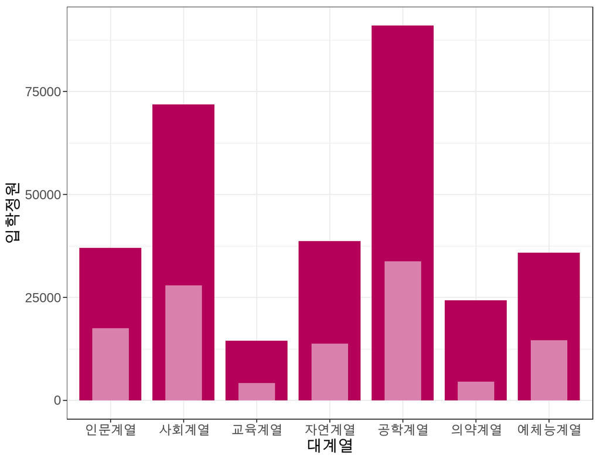

```r
quota_sum |>
  ggplot(aes(x = 대계열, y = 입학정원)) +
  geom_col(fill = '#b40059', width = 0.85) +
  geom_col(data = quota_central, fill = '#da80ac', width = 0.5) +
  theme_bw()
```

이 시각화를 보다 효율적으로 그리기 위해 각각의 막대에 해당 계열의 입학정원을 표기하고 수도권의 경우에는 전체 대비 비율을 표기하도록 하겠다.

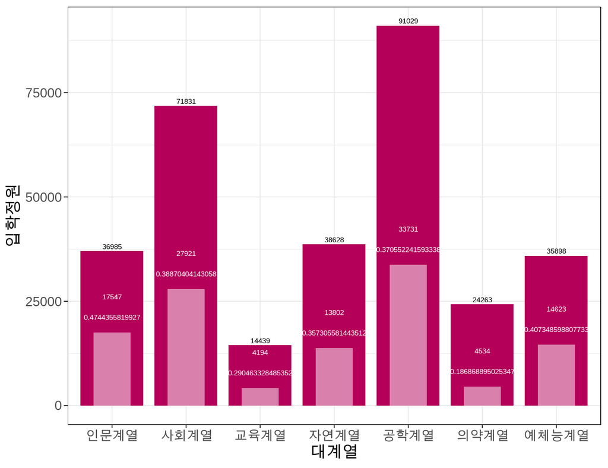

```r
quota_sum |>
  ggplot(aes(x = 대계열, y = 입학정원)) +
  geom_col(fill = '#b40059', width = 0.85) +
  geom_text(aes(x = 대계열, y = 입학정원, label = 입학정원), color = 'black', vjust = -0.5) +
  geom_col(data = quota_central, fill = '#da80ac', width = 0.5) +
  geom_text(data = quota_central, aes(x = 대계열, y = 입학정원,
                                      label = paste0(입학정원, '\n', rate)),
            color = 'white', vjust = -0.5) +
  theme_bw()
```

위의 시각화에는 몇 가지 문제가 보인다. 첫 번째 문제는 천단위 콤마가 없다는 것, 두 번째 문제는 전체 비율 표기에 소수점이 너무 많다는 점과 ‘%’ 기호가 없다는 것, 세 번째는 `paste0()`로 묶어준 문자열의 라인 간격이 너무 넓어 교육계열의 데이터가 잘 표시되지 않는다는 것, 네 번쨰는 범례가 없다는 것이다. 첫 번째 문제와 두 번째 문제는 `scales` 패키지의 `comma()`와 `percent()`를 사용하면 해결되고, 세 번째 라인 간격은 `geom_text()`의 `linehight` 매개변수를 사용하면 해결된다. 마지막 범례의 문제는 `aes()`로 매핑된 ‘fill’ 값이 없기 때문에 발생한 문제이기 떄문에 `geom_col()`의 `fill`을 각각 매핑 변수로 할당하고 `scale_fill_manual()`에 해당 매핑 변수를 색상으로 대체해주면 해결된다.

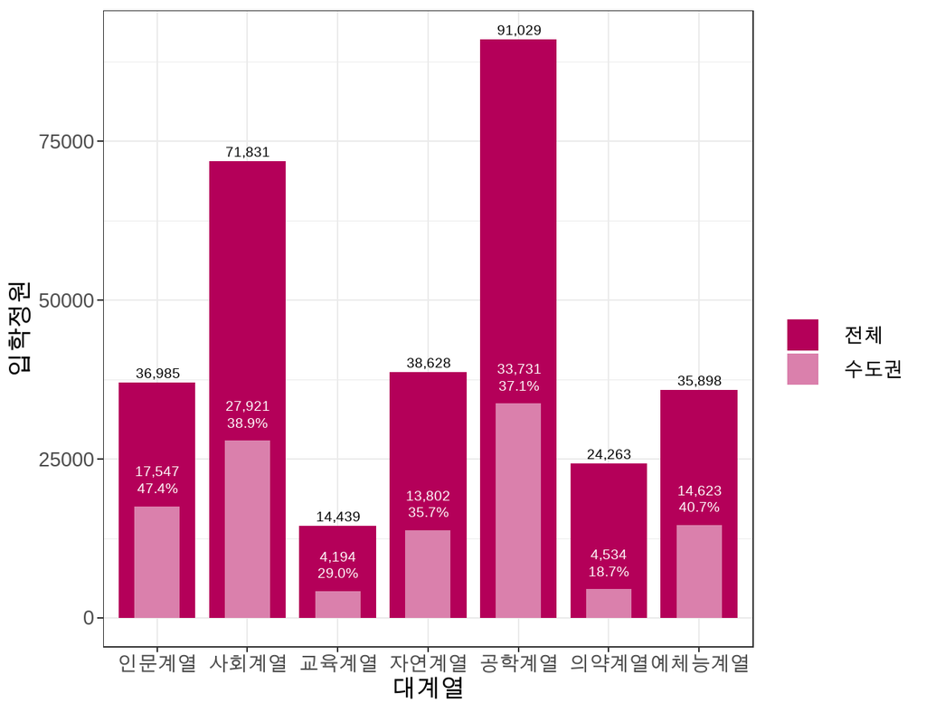

```r
quota_sum |>
  ggplot(aes(x = 대계열, y = 입학정원)) +
  geom_col(aes(fill = '전체'), width = 0.85) +
  geom_text(aes(label = scales::comma(입학정원)), color = 'black', vjust = -0.5) +
  geom_col(data = quota_central, aes(fill = '수도권'), width = 0.5) +
  geom_text(data = quota_central, aes(label = paste0(scales::comma(입학정원), '\n', scales::percent(rate))),
            color = 'white', vjust = -0.5, lineheight = 0.5) +
  scale_fill_manual(name = '', values = c('전체' = '#b40059', '수도권' = '#da80ac')) +
  theme_bw()
```